# Can a pressure against homophones explain phonological neighborhoods?

This notebook is for comparing different *baselines* of human lexica. Currently, there are three baseline models:

1) Neutral: Models only the phonotactic properties of the target lexicon. 2) Anti-Homophones: Models the phonotactic properties, along with a pressure against over-saturating wordforms with too many meanings.  
3) Anti-Homophones+: Model the phonotactic properties, along with an anti-homophone pressure––specifically, overly homophonous wordforms are converted to near-neighbors.

See the paper for more details:

> Trott, S., Bergen, B. (2022) Can a pressure against homophones explain phonological neighborhoods?

## Load libraries

```python
import pandas as pd
import numpy as np

from tqdm import tqdm
```

```python
import seaborn as sns
import matplotlib.pyplot as plt

import src.config as config
import src.utils as utils

from src.analysis import Analyzer, get_analysis_parameters
```

```python
%matplotlib inline
%config InlineBackend.figure_format = 'retina'
```

```python
plt.rcParams['figure.figsize'] = [8, 6]
```

## Analyze All Lexica Together

```python
languages = [('english', 5),
             ('dutch', 5),
             ('french', 4),
             ('german', 5),
             ('mandarin_cld', 4)
            ]
```

```python
analysis_params = []
```

```python
for language, n in languages:
    print(language)
    params = get_analysis_parameters(config, language=language)
    params['n'] = n

    analyzer = Analyzer(**params)
    analyzer.load_real_lexica()
    analyzer.load_artificial_lexica()

    real_params = analyzer.extract_params(analyzer.df_processed)
    real_params['mode'] = 'real'

    # analyzer.artificial_lexica = analyzer.artificial_lexica[0:9]

    analysis_params.append(real_params)
    for i in tqdm(analyzer.artificial_lexica):
        fake_params = analyzer.extract_params(i)
        fake_params['mode'] = i['mode'].values[0]
        analysis_params.append(fake_params)
```

```
english
41887 entries in original lexicon.
35107 processed entries.
```

```
dutch
67583 entries in original lexicon.
65260 processed entries.
```

```
french
43782 entries in original lexicon.
37278 processed entries.
```

```
german
51718 entries in original lexicon.
50435 processed entries.
```

```
mandarin_cld
```

```
45552 entries in original lexicon.
```

```
41009 processed entries.
```

```python
len(analysis_params)
```

```
155
```

```python
df_analysis = pd.concat(analysis_params)
```

```python
language_mapping = {
    'english': 'English',
    'german': 'German',
    'dutch': 'Dutch',
    'french': 'French',
    'mandarin': 'Mandarin (CallHome)',
    'mandarin_cld': 'Mandarin (CLD)'
}

mode_mapping = {
    'neutral': 'Neutral',
    'anti_homophones': 'Anti-Homophony',
    'anti_homophones_plus': 'Anti-Homophony+',
    'real': 'Real'
}
```

```python
df_analysis['language'] = df_analysis['language'].apply(lambda x: language_mapping[x])
df_analysis['mode'] = df_analysis['mode'].apply(lambda x: mode_mapping[x])
```

### Homophone results

```python
plt.rcParams['figure.figsize'] = [12, 6]
```

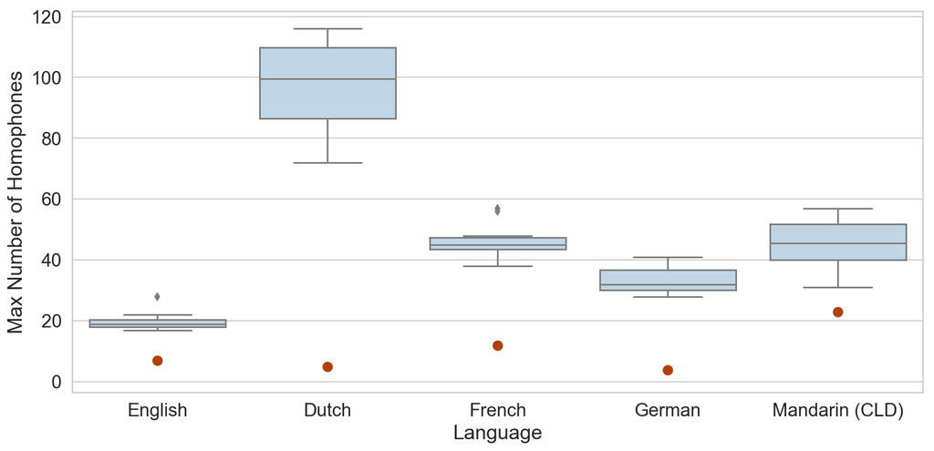

```python
sns.set(font_scale = 1.5)
sns.set_style("whitegrid")
sns.boxplot(data = df_analysis[df_analysis['mode']=='Neutral'],
               x = 'language',
               y = 'max_homophones',
               # hue = "mode",
              color = sns.color_palette("Blues")[1])

sns.scatterplot(data = df_analysis[df_analysis['mode']=='Real'],
               x = 'language',
               y = 'max_homophones',
                # style='.',
                s = 100,
                color = sns.color_palette("dark")[1])


plt.tight_layout()
plt.ylabel("Max Number of Homophones")
plt.xlabel("Language")
plt.savefig("Figures/max_homophones.png", dpi=300)
```

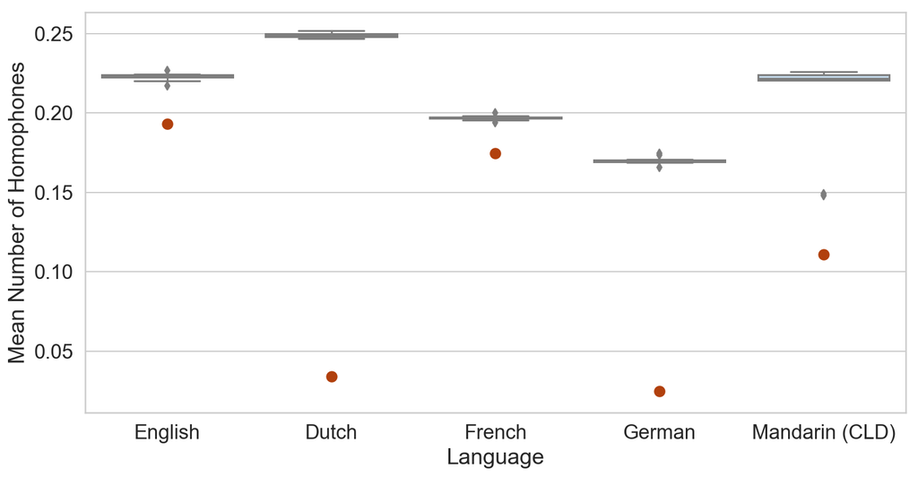

```python
# sns.set(rc={'figure.figsize':(20, 6)})
sns.set_style("whitegrid")
sns.boxplot(data = df_analysis[df_analysis['mode']=='Neutral'],
               x = 'language',
               y = 'mean_homophones',
               # hue = "mode",
              color = sns.color_palette("Blues")[1])

sns.scatterplot(data = df_analysis[df_analysis['mode']=='Real'],
               x = 'language',
               y = 'mean_homophones',
                s = 100,
                color = sns.color_palette("dark")[1])


plt.ylabel("Mean Number of Homophones")
plt.xlabel("Language")
plt.savefig("Figures/mean_homophones.png", dpi=300)
```

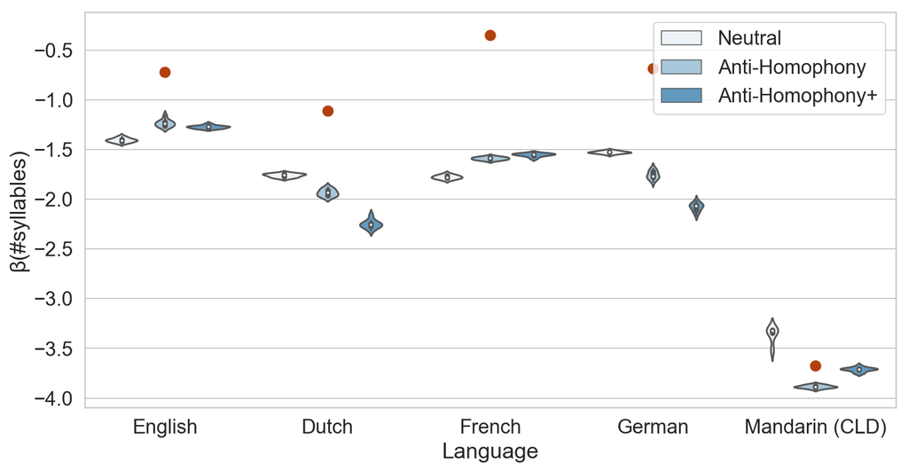

```python
sns.set_style("whitegrid")
sns.violinplot(data = df_analysis[df_analysis['mode']!='Real'],
               x = 'language',
               y = 'num_sylls_est',
               hue = "mode",
              color = sns.color_palette("Blues")[3])

sns.scatterplot(data = df_analysis[df_analysis['mode']=='Real'],
               x = 'language',
               y = 'num_sylls_est',
                s = 100,
                color = sns.color_palette("dark")[1])


plt.ylabel("\u03B2(#syllables)")
plt.xlabel("Language")
```

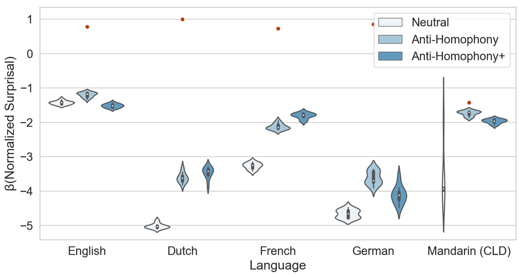

```python
sns.violinplot(data = df_analysis[df_analysis['mode']!='Real'],
               x = 'language',
               y = 'normalized_surprisal',
               hue = "mode",
              color = sns.color_palette("Blues")[3])

sns.scatterplot(data = df_analysis[df_analysis['mode']=='Real'],
               x = 'language',
               y = 'normalized_surprisal',
                color = sns.color_palette("dark")[1])

plt.ylabel("\u03B2(Normalized Surprisal)")
plt.xlabel("Language")
```

### Neighborhood results

Next, we consider the more central question: do real lexica have larger or smaller neighborhoods than the baselines?

```python
REAL = df_analysis[df_analysis['mode']=='Real']['mean_mp'].values
art = df_analysis[df_analysis['mode']!='Real']
```

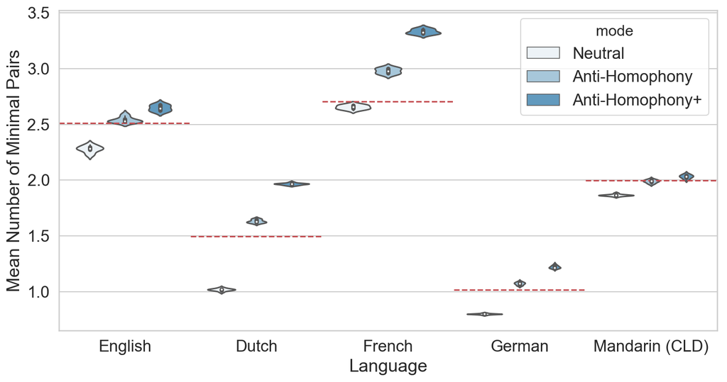

```python
sns.set_style("whitegrid")
ax = sns.violinplot(data = df_analysis[df_analysis['mode']!='Real'],
               x = 'language',
               y = 'mean_mp',
               hue = "mode",
              color = sns.color_palette("Blues")[3])

for index, r in enumerate(REAL):

    ax.axhline(r, ls='--', color='r',
              xmin = index/len(REAL),
              xmax = index/len(REAL) + .2)

plt.ylabel("Mean Number of Minimal Pairs")
plt.xlabel("Language")

plt.savefig("Figures/mean_mp.png", dpi=300)
```

```python
REAL = df_analysis[df_analysis['mode']=='Real']['max_mp'].values
```

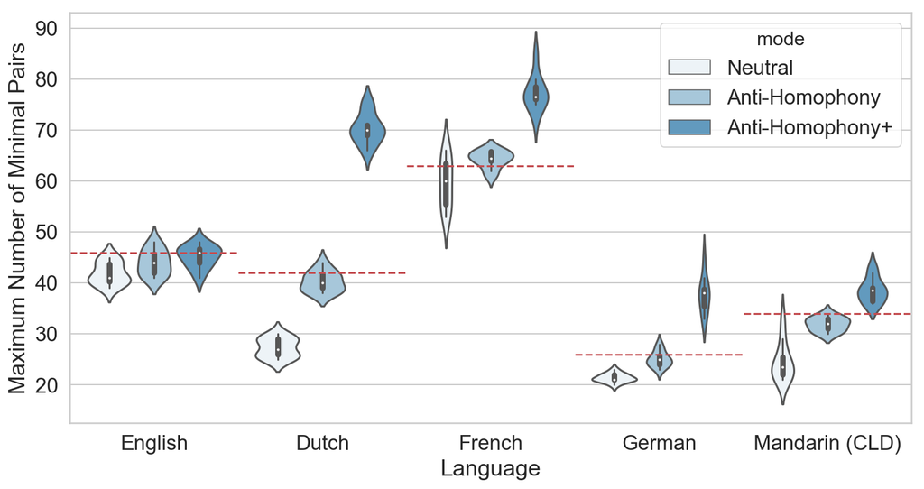

```python
sns.set_style("whitegrid")
ax = sns.violinplot(data = df_analysis[df_analysis['mode']!='Real'],
               x = 'language',
               y = 'max_mp',
               hue = "mode",
              color = sns.color_palette("Blues")[3])

for index, r in enumerate(REAL):

    ax.axhline(r, ls='--', color='r',
              xmin = index/len(REAL),
              xmax = index/len(REAL) + .2)

plt.ylabel("Maximum Number of Minimal Pairs")
plt.xlabel("Language")

plt.savefig("Figures/max_mp.png", dpi=300)
```

#### Summary statistics

```python
df_analysis[['language', 'mode', 'mean_mp']].groupby(['language', 'mode']).describe()
```

| language | mode | mean_mp count | mean_mp mean | mean_mp std | mean_mp min | mean_mp 25% | mean_mp 50% | mean_mp 75% | mean_mp max |
| --- | --- | --- | --- | --- | --- | --- | --- | --- | --- |
| Dutch | Anti-Homophony | 10.0 | 1.63221 | 0.014570 | 1.6142 | 1.622325 | 1.62660 | 1.646775 | 1.6528 |
|  | Anti-Homophony+ | 10.0 | 1.96615 | 0.008657 | 1.9536 | 1.962475 | 1.96805 | 1.969775 | 1.9832 |
|  | Neutral | 10.0 | 1.01866 | 0.010929 | 0.9969 | 1.012700 | 1.02100 | 1.021725 | 1.0375 |
|  | Real | 1.0 | 1.49810 | NaN | 1.4981 | 1.498100 | 1.49810 | 1.498100 | 1.4981 |
| English | Anti-Homophony | 10.0 | 2.54087 | 0.025878 | 2.5178 | 2.523875 | 2.53005 | 2.548300 | 2.5942 |
|  | Anti-Homophony+ | 10.0 | 2.64829 | 0.027558 | 2.6132 | 2.626125 | 2.64495 | 2.674125 | 2.6873 |
|  | Neutral | 10.0 | 2.27931 | 0.029703 | 2.2257 | 2.272500 | 2.28400 | 2.294775 | 2.3186 |
|  | Real | 1.0 | 2.51400 | NaN | 2.5140 | 2.514000 | 2.51400 | 2.514000 | 2.5140 |
| French | Anti-Homophony | 10.0 | 2.98062 | 0.024731 | 2.9459 | 2.959925 | 2.97865 | 3.002250 | 3.0127 |
|  | Anti-Homophony+ | 10.0 | 3.33277 | 0.021606 | 3.3052 | 3.319025 | 3.32520 | 3.349125 | 3.3647 |
|  | Neutral | 10.0 | 2.65599 | 0.019174 | 2.6262 | 2.641925 | 2.65560 | 2.671175 | 2.6822 |
|  | Real | 1.0 | 2.70600 | NaN | 2.7060 | 2.706000 | 2.70600 | 2.706000 | 2.7060 |
| German | Anti-Homophony | 10.0 | 1.07314 | 0.012598 | 1.0545 | 1.063050 | 1.07445 | 1.082025 | 1.0925 |
|  | Anti-Homophony+ | 10.0 | 1.22213 | 0.012849 | 1.2047 | 1.214650 | 1.21665 | 1.231550 | 1.2471 |
|  | Neutral | 10.0 | 0.80002 | 0.004998 | 0.7904 | 0.798500 | 0.79935 | 0.801500 | 0.8100 |
|  | Real | 1.0 | 1.01870 | NaN | 1.0187 | 1.018700 | 1.01870 | 1.018700 | 1.0187 |
| Mandarin (CLD) | Anti-Homophony | 10.0 | 1.99024 | 0.014037 | 1.9669 | 1.982725 | 1.99210 | 1.999875 | 2.0107 |
|  | Anti-Homophony+ | 10.0 | 2.03311 | 0.016600 | 2.0042 | 2.024150 | 2.03435 | 2.042300 | 2.0568 |
|  | Neutral | 10.0 | 1.86604 | 0.008286 | 1.8525 | 1.862700 | 1.86400 | 1.869225 | 1.8846 |
|  | Real | 1.0 | 1.99730 | NaN | 1.9973 | 1.997300 | 1.99730 | 1.997300 | 1.9973 |

```python
df_analysis[['language', 'mode', 'max_mp']].groupby(['language', 'mode']).describe()
```

| language | mode | max_mp count | max_mp mean | max_mp std | max_mp min | max_mp 25% | max_mp 50% | max_mp 75% | max_mp max |
| --- | --- | --- | --- | --- | --- | --- | --- | --- | --- |
| Dutch | Anti-Homophony | 10.0 | 40.3 | 2.002776 | 38.0 | 39.00 | 40.0 | 41.75 | 44.0 |
|  | Anti-Homophony+ | 10.0 | 70.3 | 2.945807 | 66.0 | 69.00 | 70.0 | 71.00 | 75.0 |
|  | Neutral | 10.0 | 27.3 | 1.888562 | 25.0 | 26.00 | 27.0 | 29.00 | 30.0 |
|  | Real | 1.0 | 42.0 | NaN | 42.0 | 42.00 | 42.0 | 42.00 | 42.0 |
| English | Anti-Homophony | 10.0 | 44.0 | 2.494438 | 41.0 | 42.00 | 44.0 | 45.75 | 48.0 |
|  | Anti-Homophony+ | 10.0 | 45.2 | 2.149935 | 41.0 | 44.00 | 46.0 | 46.75 | 48.0 |
|  | Neutral | 10.0 | 41.9 | 2.183270 | 39.0 | 40.25 | 41.0 | 43.75 | 45.0 |
|  | Real | 1.0 | 46.0 | NaN | 46.0 | 46.00 | 46.0 | 46.00 | 46.0 |
| French | Anti-Homophony | 10.0 | 64.3 | 1.702939 | 61.0 | 64.00 | 64.5 | 65.75 | 66.0 |
|  | Anti-Homophony+ | 10.0 | 77.3 | 3.465705 | 72.0 | 76.00 | 76.5 | 78.50 | 85.0 |
|  | Neutral | 10.0 | 59.7 | 4.854551 | 53.0 | 55.50 | 60.0 | 63.50 | 66.0 |
|  | Real | 1.0 | 63.0 | NaN | 63.0 | 63.00 | 63.0 | 63.00 | 63.0 |
| German | Anti-Homophony | 10.0 | 25.1 | 1.523884 | 23.0 | 24.00 | 25.0 | 25.75 | 28.0 |
|  | Anti-Homophony+ | 10.0 | 37.7 | 3.622461 | 33.0 | 35.50 | 38.0 | 38.75 | 45.0 |
|  | Neutral | 10.0 | 21.4 | 0.843274 | 20.0 | 21.00 | 21.0 | 22.00 | 23.0 |
|  | Real | 1.0 | 26.0 | NaN | 26.0 | 26.00 | 26.0 | 26.00 | 26.0 |
| Mandarin (CLD) | Anti-Homophony | 10.0 | 31.9 | 1.370320 | 30.0 | 31.00 | 32.0 | 33.00 | 34.0 |
|  | Anti-Homophony+ | 10.0 | 38.6 | 2.412928 | 36.0 | 36.50 | 38.5 | 39.00 | 43.0 |
|  | Neutral | 10.0 | 24.6 | 3.777124 | 21.0 | 22.00 | 23.5 | 25.50 | 33.0 |
|  | Real | 1.0 | 34.0 | NaN | 34.0 | 34.00 | 34.0 | 34.00 | 34.0 |

## Compare rank distributions

Finally, we directly compare the **rank distributions**, so that we can evaluate the predictive power of each baseline. That is, which model comes closest to recreating the real distribution of neighborhood sizes?

```python
language_mapping = {
    'english': 'English',
    'german': 'German',
    'dutch': 'Dutch',
    'french': 'French',
    'mandarin_cld': 'Mandarin (CLD)'
}

mode_mapping = {
    'neutral': 'Neutral',
    'anti_homophones': 'Anti-Homophony',
    'anti_homophones_plus': 'Anti-Homophony+',
    'real': 'Real'
}
```

```python
all_languages = []
for language, n in languages:
    params = get_analysis_parameters(config, language=language)
    params['n'] = n

    analyzer = Analyzer(**params)
    analyzer.load_real_lexica()
    analyzer.load_artificial_lexica()

    # Get length of minimum-sized lexicon
    all_lexica = analyzer.artificial_lexica + [analyzer.df_processed]
    lengths = [len(l) for l in all_lexica]
    topN = min(lengths)

    ## Ranks
    df_ranks = analyzer.aggregate_rank_distributions('neighborhood_size', rank_N = topN)
    df_ranks['language'] = language

    all_languages.append(df_ranks)
```

```
41887 entries in original lexicon.
35107 processed entries.
67583 entries in original lexicon.
65260 processed entries.
43782 entries in original lexicon.
37278 processed entries.
51718 entries in original lexicon.
50435 processed entries.
```

```
45552 entries in original lexicon.
```

```
41009 processed entries.
```

```python
df_all = pd.concat(all_languages)
```

```python
df_all['Language'] = df_all['language'].apply(lambda x: language_mapping[x])
df_all['Mode'] = df_all['mode'].apply(lambda x: mode_mapping[x])
```

```python
sns.set(font_scale = 1.5)
sns.set_style("whitegrid")
```

```python
### Fit models...
### Change top N?
import math
results = []
for language, n in languages:

    df_subset = df_all[df_all['language'] == language]
    df_real = df_subset[df_subset['mode']=='real']
    real_dist = np.array(sorted(df_real['neighborhood_size'].values, reverse = False))

    for mode in ['neutral', 'anti_homophones', 'anti_homophones_plus']:
        df_art = df_subset[df_subset['mode']==mode]
        art_dist = np.array(sorted(df_art['neighborhood_size'].values, reverse = False))

        diff = art_dist - real_dist
        SSE = sum(diff**2)
        MSE = SSE/len(diff)
        RMSE = math.sqrt(MSE)

        # RMSE =

        results.append({
            'language': language,
            'mode': mode,
            'SSE': SSE,
            'MSE': MSE,
            'RMSE': RMSE,
            'MAE': sum(abs(diff))/len(diff),
            'ME': sum(diff)/len(diff),
            'N': len(diff)
        })
```

```python
df_results = pd.DataFrame(results)
```

```python
df_results['Language'] = df_results['language'].apply(lambda x: language_mapping[x])
df_results['Mode'] = df_results['mode'].apply(lambda x: mode_mapping[x])
```

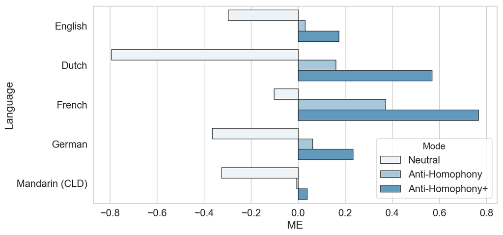

```python
ax  = sns.barplot(data = df_results,
           y = 'Language',
           x = 'ME',
           hue = 'Mode',
           color = sns.color_palette("Blues")[3],
                 edgecolor=".2")


plt.setp(ax.patches, linewidth=1)

plt.savefig("Figures/me.png", dpi=300, bbox_inches = 'tight')
```

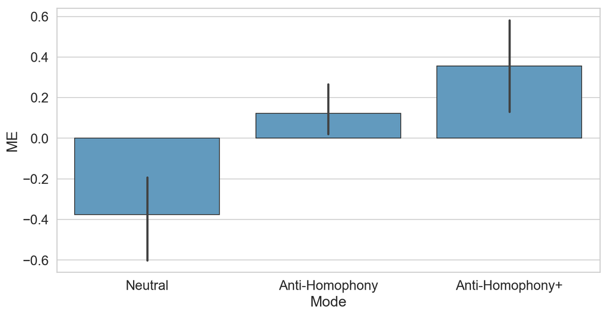

```python
sns.barplot(data = df_results,
           x = 'Mode',
           y = 'ME',
           color = sns.color_palette("Blues")[3],
                 edgecolor=".2")



# plt.savefig("Figures/me.png", dpi=300)
```